# REVISED FINAL Action Seniors - CogFrailty Analyses (November 3, 2022)

RSF

2022-11-03

# 1) Data set-up and management

```r
if (!require("pacman")) install.packages("pacman")
```

```r
pacman::p_load(boot,MASS,readxl,mediation,plyr,sandwich,ggplot2,lme4,lmerTest,rpart,survival,survminer,lsmeans,fmsb, mice, mitools, tableone)


setwd("~/Desktop/Manuscripts/Ongoing Projects/ActionSeniors! Cognitive Frailty/")
data<-read_excel("ActionSeniors_CogsSPPB.xlsx")#Data#

data$CogFrail<-NA
data$CogFrail[data$SPPB_1<=9 & data$MoCA_1<26]<-"Yes"
data$CogFrail[data$SPPB_1>9 | data$MoCA_1>=26]<-"No"

data$exclude<-0
data$exclude[data$ID==330]<-1

data$Group.1<-NA
data$Group.1[data$Group==0]<-"Interview"
data$Group.1[data$Group==1]<-"Otago"

data$Group_r[data$Group==0]<-1
data$Group_r[data$Group==1]<-0

data$Gender<-NA
data$Gender[data$Sex==1]<-0
data$Gender[data$Sex==2]<-1

CogFrail<- subset(data, CogFrail=="Yes")

CogFrail$exclude<-0
CogFrail$exclude[CogFrail$ID==330]<-1

CogFrail$Group.1<-NA
CogFrail$Group.1[CogFrail$Group==0]<-"Interview"
CogFrail$Group.1[CogFrail$Group==1]<-"Otago"

CogFrail$Group_r[CogFrail$Group==0]<-1
CogFrail$Group_r[CogFrail$Group==1]<-0

CogFrail$Gender<-NA
CogFrail$Gender[CogFrail$Sex==1]<-0
CogFrail$Gender[CogFrail$Sex==2]<-1

No_CogFrail<- subset(data, CogFrail=="No")

No_CogFrail$exclude<-0
No_CogFrail$exclude[No_CogFrail$ID==330]<-1

No_CogFrail$Group.1<-NA
No_CogFrail$Group.1[No_CogFrail$Group==0]<-"Interview"
No_CogFrail$Group.1[No_CogFrail$Group==1]<-"Otago"

No_CogFrail$Group_r[No_CogFrail$Group==0]<-1
No_CogFrail$Group_r[No_CogFrail$Group==1]<-0

No_CogFrail$Gender<-NA
No_CogFrail$Gender[No_CogFrail$Sex==1]<-0
No_CogFrail$Gender[No_CogFrail$Sex==2]<-1


#Create long data set
library(plyr)
wide<-rename(data,c("Weight_1"="Weightbaseline", "Height_1"="Heightbaseline","BMI_1"="BMIbaseline",
                    "Falls 12M prior to baseline"="Fallsbeforebaseline", "Total_Exposure"="TotalExposure",
                    "Total_Falls"="TotalFalls","PPA_1"="PPAbaseline","GDS_1"="GDSbaseline","MoCA_1"="MoCAbaseline",
                    "Trails_BA_1"="TrailsBAbaseline","DSST_1"="DSSTbaseline","TUG_1"="TUGbaseline",
                    "SPPB_1"="SPPBbaseline","Gait_Speed_1"="GaitSpeedbaseline","Trails_BA_2"="TrailsBA_2",
                    "Trails_BA_3"="TrailsBA_3","Group_r"="Group.r","Gait_Speed_2"="GaitSpeed_2","Gait_Speed_3"="GaitSpeed_3"))
detach("package:plyr", unload = TRUE)

wide$StroopINTbaseline<-as.numeric(wide$Stroop_3_1) - as.numeric(wide$Stroop_2_1)
wide$StroopINT_2<-as.numeric(wide$Stroop_3_2) - as.numeric(wide$Stroop_2_2)
wide$StroopINT_3<-as.numeric(wide$Stroop_3_3) - as.numeric(wide$Stroop_2_3)

wide$DigitsFBbaseline<- wide$Digits_F_1 - wide$Digits_B_1
wide$DigitsFB_2<- wide$Digits_F_2 - wide$Digits_B_2
wide$DigitsFB_3<- wide$Digits_F_3 - wide$Digits_B_3

wide$time<-1

wide2<-wide[c(1,76,2:12,15,16,17,64:69,13,14,18,21,27,28,29,31,70,73,
              32:34,37,43:45,47,71,74,48:50,53,59:61,63,72,75)]
data2 <- reshape(as.data.frame(wide2),idvar="ID",varying=c(33:52),direction="long",sep="_")

CogFrail$Females<-NA
CogFrail$Females[CogFrail$Gender==1]<-"Female"
CogFrail$Females[CogFrail$Gender==0]<-"Male"

No_CogFrail$Females<-NA
No_CogFrail$Females[No_CogFrail$Gender==1]<-"Female"
No_CogFrail$Females[No_CogFrail$Gender==0]<-"Male"
```

# 2) Compliance data set-up

Note: All analyses used estimated average compliance for Cognitively Frail participants (44.0%) and non-CogFrail participants (51.1%). High compliance is ≥ mean compliance for each group.

```r
setwd("~/Desktop/Manuscripts/Ongoing Projects/ActionSeniors! Cognitive Frailty/")
compliancedata<-read_excel("jcd AS_compliance_Jul 2021.xlsx", sheet = "Compliance_for analysis") #Data#
```

```
## * `` -> ...69
```

```r
compliancedata2<-compliancedata[c(1,7,11,15,19,23,27,31,35,39,43,47,51,55,66)]
compliancedata2<-compliancedata2[-c(173:177),]
library(plyr)
compliancedata2<-rename(compliancedata2, c("id"="ID"))
detach("package:plyr", unload = TRUE)

OEP<-subset(wide, Group == 1)
compliancedata3<-merge(OEP,compliancedata2, by = c("ID"))
compliancedata3<-compliancedata3[c(1,3,65,77:90)]
library(plyr)
compliancedata3<-rename(compliancedata3, c("OEPCOMP1"="OEPCOMP_1","OEPCOMP2"="OEPCOMP_2","OEPCOMP3"="OEPCOMP_3","OEPCOMP4"="OEPCOMP_4","OEPCOMP5"="OEPCOMP_5","OEPCOMP6"="OEPCOMP_6",
                                           "OEPCOMP7"="OEPCOMP_7","OEPCOMP8"="OEPCOMP_8","OEPCOMP9"="OEPCOMP_9","OEPCOMP10"="OEPCOMP_10","OEPCOMP11"="OEPCOMP_11","OEPCOMP12"="OEPCOMP_12",
                                           "OEPCOMP13"="OEPCOMP_13"))
detach("package:plyr", unload = TRUE)

#long form
compliancelong <- reshape(as.data.frame(compliancedata3),idvar="ID",varying=c(4:16),direction="long",sep="_")

#Maximize compliance at 100% (i.e., compliance cannot be greater than 100%, regardless of how many times/month OEP was completed)
compliancelong$OEPCOMP[compliancelong$OEPCOMP>100]<-100

#Maximize compliance at 100% for each individual month
compliancedata2$OEPCOMP1[compliancedata2$OEPCOMP1>100]<-100
compliancedata2$OEPCOMP2[compliancedata2$OEPCOMP2>100]<-100
compliancedata2$OEPCOMP3[compliancedata2$OEPCOMP3>100]<-100
compliancedata2$OEPCOMP4[compliancedata2$OEPCOMP4>100]<-100
compliancedata2$OEPCOMP5[compliancedata2$OEPCOMP5>100]<-100
compliancedata2$OEPCOMP6[compliancedata2$OEPCOMP6>100]<-100
compliancedata2$OEPCOMP7[compliancedata2$OEPCOMP7>100]<-100
compliancedata2$OEPCOMP8[compliancedata2$OEPCOMP8>100]<-100
compliancedata2$OEPCOMP9[compliancedata2$OEPCOMP9>100]<-100
compliancedata2$OEPCOMP10[compliancedata2$OEPCOMP10>100]<-100
compliancedata2$OEPCOMP11[compliancedata2$OEPCOMP11>100]<-100
compliancedata2$OEPCOMP12[compliancedata2$OEPCOMP12>100]<-100
compliancedata2$OEPCOMP13[compliancedata2$OEPCOMP13>100]<-100

compliancedata2$AverageComply<-(compliancedata2[c(2)] + compliancedata2[c(3)] + compliancedata2[c(4)] + compliancedata2[c(5)] + compliancedata2[c(6)] + compliancedata2[c(7)] +
                                  compliancedata2[c(8)] + compliancedata2[c(9)] + compliancedata2[c(10)] + compliancedata2[c(11)] + compliancedata2[c(12)] + compliancedata2[c(13)] +
                                  compliancedata2[c(14)])/13

OEP2<-subset(wide2, Group == 1)


#Determine compliant vs. non compiant for CogFrail and Non-Frail
OEP2$Compliant<-NA
OEP2$Compliant[compliancedata2$AverageComply>=51.1 & OEP$CogFrail=="No" | compliancedata2$AverageComply>=44.0 & OEP$CogFrail=="Yes"] <- "Yes"
OEP2$Compliant[compliancedata2$AverageComply<51.1 & OEP$CogFrail=="No" | compliancedata2$AverageComply<44.0 & OEP$CogFrail=="Yes"] <- "No"

OEP3 <- reshape(as.data.frame(OEP2),idvar="ID",varying=c(33:52),direction="long",sep="_")
```

# 3) Figure 1 - CONSORT Flow Chart Stratified by Cognitive Frailty Status

```r
#Determine CogFrail Status of Dropouts
CONSORT<- subset(wide2, ID==128 | ID== 131 | ID==132 | ID==134 | ID==158 | ID==163 | ID==176 | ID==185 | ID==192 | ID==195 | ID==213 | ID==214 | ID==216 | ID==220 | ID==222 | ID==223 |
                   ID==270 | ID==278 | ID==281 | ID==284 | ID==306 | ID==310 | ID==318 | ID==321 | ID==330 | ID==334 | ID==339 | ID==357 | ID==362 | ID==369 | ID==373 | ID==375 | ID==378 |
                   ID==385 | ID==395 | ID==398 | ID==407 | ID==408 | ID==412 | ID==413 | ID==424 | ID==426 | ID==427 | ID==428 | ID==432 | ID==438 | ID==455 | ID==461) #All dropouts

CONSORT<-CONSORT[c(1,3,18)]
MONTHS<- c(13,2,1,0,0,0,13,0,0,13,2,4,0,11,3,5,1,5,2,5,0,0,3,0,0,5,0,4,5,5,5,7,6,1,1,9,1,7,9,2,4,1,7,7,5,11,7,10) #Months in study before drop-out
CONSORT<-cbind(CONSORT,MONTHS)

CONSORT$Group[CONSORT$Group==1]<-"INT"
CONSORT$Group[CONSORT$Group==0]<-"CON"

#Dropouts before 6 months (i.e., Month 7) or after 6 months in study
CONSORT$Timepoint<-NA
CONSORT$Timepoint[CONSORT$MONTHS<=7]<-"6 Months or Less"
CONSORT$Timepoint[CONSORT$MONTHS>7]<-"More than 6 Months"


#Sort by Group, Cognitive Frailty Status, and Time of Dropout
table(CONSORT$Timepoint,CONSORT$Group, CONSORT$CogFrail)
```

```
## , ,  = No
##
##
##                      CON INT
##   6 Months or Less     8   9
##   More than 6 Months   2   1
##
## , ,  = Yes
##
##
##                      CON INT
##   6 Months or Less    10  12
##   More than 6 Months   1   4
```

# 4) Table 1 - Participant Characteristics

```r
#Descriptive statistics for cognitively frail participants
cogfrail_vars<-dput(names(CogFrail[c(4,70,7,8,9,13,15,16,18,28,29,31)]))
```

```
## c("Age", "Females", "BMI_1", "Education", "Falls 12M prior to baseline",
## "PPA_1", "FCI", "IADL", "MoCA_1", "TUG_1", "SPPB_1", "Gait_Speed_1"
## )
```

```r
Table1_cogfrail_vars<-CreateTableOne(vars=cogfrail_vars, strata="Group", data=CogFrail)
print(Table1_cogfrail_vars,contDigits=2,missing=TRUE,quote=TRUE)
```

```
##                                                      "Stratified by Group"
##  ""                                                   "0"
##   "n"                                                 "   99"
##   "Age (mean (SD))"                                   "83.31 (5.88)"
##   "Females = Male (%)"                                "   62 (62.6) "
##   "BMI_1 (mean (SD))"                                 "27.03 (4.80)"
##   "Education (%)"                                     "   "
##   "   Grades 9-13, without certificate or diploma"    "   15 (15.2) "
##   "   High school certificate or diploma"             "   18 (18.2) "
##   "   Less than grade 9"                              "    2 ( 2.0) "
##   "   Some university without certificate or diploma" "    8 ( 8.1) "
##   "   Trades or professional certificate or diploma"  "   14 (14.1) "
##   "   University certificate or diploma"              "    4 ( 4.0) "
##   "   University degree"                              "   38 (38.4) "
##   "Falls 12M prior to baseline (mean (SD))"           " 2.84 (5.57)"
##   "PPA_1 (mean (SD))"                                 " 2.20 (0.98)"
##   "FCI (mean (SD))"                                   " 4.04 (1.93)"
##   "IADL (mean (SD))"                                  " 7.17 (1.27)"
##   "MoCA_1 (mean (SD))"                                "21.90 (2.38)"
##   "TUG_1 (mean (SD))"                                 "18.68 (6.76)"
##   "SPPB_1 (mean (SD))"                                " 6.70 (1.88)"
##   "Gait_Speed_1 (mean (SD))"                          " 0.80 (0.23)"
##                                                      "Stratified by Group"
##  ""                                                   "1"             "p"
##   "n"                                                 "   93"         ""
##   "Age (mean (SD))"                                   "81.62 (6.55)"  " 0.061"
##   "Females = Male (%)"                                "   61 (65.6) " " 0.781"
##   "BMI_1 (mean (SD))"                                 "28.16 (8.79)"  " 0.269"
##   "Education (%)"                                     "   "           " 0.260"
##   "   Grades 9-13, without certificate or diploma"    "    5 ( 5.4) " ""
##   "   High school certificate or diploma"             "   20 (21.5) " ""
##   "   Less than grade 9"                              "    6 ( 6.5) " ""
##   "   Some university without certificate or diploma" "    8 ( 8.6) " ""
##   "   Trades or professional certificate or diploma"  "   15 (16.1) " ""
##   "   University certificate or diploma"              "    6 ( 6.5) " ""
##   "   University degree"                              "   33 (35.5) " ""
##   "Falls 12M prior to baseline (mean (SD))"           " 2.47 (2.58)"  " 0.565"
##   "PPA_1 (mean (SD))"                                 " 2.15 (0.99)"  " 0.737"
##   "FCI (mean (SD))"                                   " 4.02 (2.03)"  " 0.948"
##   "IADL (mean (SD))"                                  " 7.14 (1.34)"  " 0.859"
```

[output cut: 11 more lines]

```
##   "   Grades 9-13, without certificate or diploma"    ""     "   "
##   "   High school certificate or diploma"             ""     "   "
##   "   Less than grade 9"                              ""     "   "
##   "   Some university without certificate or diploma" ""     "   "
##   "   Trades or professional certificate or diploma"  ""     "   "
##   "   University certificate or diploma"              ""     "   "
##   "   University degree"                              ""     "   "
##   "Falls 12M prior to baseline (mean (SD))"           ""     "0.0"
##   "PPA_1 (mean (SD))"                                 ""     "0.0"
##   "FCI (mean (SD))"                                   ""     "0.5"
##   "IADL (mean (SD))"                                  ""     "0.5"
##   "MoCA_1 (mean (SD))"                                ""     "0.0"
##   "TUG_1 (mean (SD))"                                 ""     "0.5"
##   "SPPB_1 (mean (SD))"                                ""     "0.0"
##   "Gait_Speed_1 (mean (SD))"                          ""     "0.0"
```

```r
#Descriptive statistics for non-cognitively frail participants
nocogfrail_vars<-dput(names(No_CogFrail[c(4,70,7,8,9,13,15,16,18,28,29,31)]))
```

```
## c("Age", "Females", "BMI_1", "Education", "Falls 12M prior to baseline",
## "PPA_1", "FCI", "IADL", "MoCA_1", "TUG_1", "SPPB_1", "Gait_Speed_1"
## )
```

```r
Table1_nocogfrail_vars<-CreateTableOne(vars=nocogfrail_vars, strata="Group", data=No_CogFrail)
print(Table1_nocogfrail_vars,contDigits=2,missing=TRUE,quote=TRUE)
```

```
##                                                      "Stratified by Group"
##  ""                                                   "0"
##   "n"                                                 "   73"
##   "Age (mean (SD))"                                   "80.01 (5.84)"
##   "Females = Male (%)"                                "   57 (78.1) "
##   "BMI_1 (mean (SD))"                                 "27.09 (5.06)"
##   "Education (%)"                                     "   "
##   "   Grades 9-13, without certificate or diploma"    "    5 ( 6.8) "
##   "   High school certificate or diploma"             "   14 (19.2) "
##   "   Less than grade 9"                              "    0 ( 0.0) "
##   "   Some university without certificate or diploma" "    6 ( 8.2) "
##   "   Trades or professional certificate or diploma"  "    7 ( 9.6) "
##   "   University certificate or diploma"              "    5 ( 6.8) "
##   "   University degree"                              "   36 (49.3) "
##   "Falls 12M prior to baseline (mean (SD))"           " 1.67 (1.95)"
##   "PPA_1 (mean (SD))"                                 " 1.57 (1.20)"
##   "FCI (mean (SD))"                                   " 3.88 (2.06)"
##   "IADL (mean (SD))"                                  " 7.62 (0.83)"
##   "MoCA_1 (mean (SD))"                                "25.38 (3.28)"
##   "TUG_1 (mean (SD))"                                 "14.45 (4.94)"
##   "SPPB_1 (mean (SD))"                                " 9.36 (1.97)"
##   "Gait_Speed_1 (mean (SD))"                          " 0.96 (0.20)"
##                                                      "Stratified by Group"
##  ""                                                   "1"             "p"
##   "n"                                                 "   79"         ""
##   "Age (mean (SD))"                                   "80.71 (5.53)"  " 0.452"
##   "Females = Male (%)"                                "   49 (62.0) " " 0.048"
##   "BMI_1 (mean (SD))"                                 "25.98 (7.38)"  " 0.286"
##   "Education (%)"                                     "   "           " 0.454"
##   "   Grades 9-13, without certificate or diploma"    "    9 (11.5) " ""
##   "   High school certificate or diploma"             "    8 (10.3) " ""
##   "   Less than grade 9"                              "    1 ( 1.3) " ""
##   "   Some university without certificate or diploma" "    8 (10.3) " ""
##   "   Trades or professional certificate or diploma"  "   12 (15.4) " ""
##   "   University certificate or diploma"              "    3 ( 3.8) " ""
##   "   University degree"                              "   37 (47.4) " ""
##   "Falls 12M prior to baseline (mean (SD))"           " 1.80 (1.89)"  " 0.686"
##   "PPA_1 (mean (SD))"                                 " 1.64 (1.07)"  " 0.685"
##   "FCI (mean (SD))"                                   " 4.11 (2.38)"  " 0.512"
##   "IADL (mean (SD))"                                  " 7.38 (1.03)"  " 0.122"
```

[output cut: 11 more lines]

```
##   "   Grades 9-13, without certificate or diploma"    ""     "   "
##   "   High school certificate or diploma"             ""     "   "
##   "   Less than grade 9"                              ""     "   "
##   "   Some university without certificate or diploma" ""     "   "
##   "   Trades or professional certificate or diploma"  ""     "   "
##   "   University certificate or diploma"              ""     "   "
##   "   University degree"                              ""     "   "
##   "Falls 12M prior to baseline (mean (SD))"           ""     "0.0"
##   "PPA_1 (mean (SD))"                                 ""     "0.0"
##   "FCI (mean (SD))"                                   ""     "0.7"
##   "IADL (mean (SD))"                                  ""     "0.0"
##   "MoCA_1 (mean (SD))"                                ""     "0.0"
##   "TUG_1 (mean (SD))"                                 ""     "0.0"
##   "SPPB_1 (mean (SD))"                                ""     "0.0"
##   "Gait_Speed_1 (mean (SD))"                          ""     "0.0"
```

# 5) Supplementary Material S1 - Differences in baseline characteristics by Cognitive Frailty status

```r
Supp<-wide2
Supp$Females<-NA
Supp$Females[Supp$Sex==1]<-"Female"
Supp$Females[Supp$Sex==2]<-"Male"

supp_vars<-dput(names(Supp[c(5,53,8,9,10,14,15,23,25,28,29,30)]))
```

```
## c("Age", "Females", "BMIbaseline", "Education", "Fallsbeforebaseline",
## "FCI", "IADL", "PPAbaseline", "MoCAbaseline", "TUGbaseline",
## "SPPBbaseline", "GaitSpeedbaseline")
```

```r
SuppTable1<-CreateTableOne(vars=supp_vars, strata="CogFrail", data=Supp)
print(SuppTable1, contDigits=2, missing=TRUE, quote=TRUE)
```

```
##                                                      "Stratified by CogFrail"
##  ""                                                   "No"
##   "n"                                                 "  152"
##   "Age (mean (SD))"                                   "80.38 (5.67)"
##   "Females = Male (%)"                                "   46 (30.3) "
##   "BMIbaseline (mean (SD))"                           "26.51 (6.38)"
##   "Education (%)"                                     "   "
##   "   Grades 9-13, without certificate or diploma"    "   14 ( 9.3) "
##   "   High school certificate or diploma"             "   22 (14.6) "
##   "   Less than grade 9"                              "    1 ( 0.7) "
##   "   Some university without certificate or diploma" "   14 ( 9.3) "
##   "   Trades or professional certificate or diploma"  "   19 (12.6) "
##   "   University certificate or diploma"              "    8 ( 5.3) "
##   "   University degree"                              "   73 (48.3) "
##   "Fallsbeforebaseline (mean (SD))"                   " 1.74 (1.91)"
##   "FCI (mean (SD))"                                   " 4.00 (2.23)"
##   "IADL (mean (SD))"                                  " 7.49 (0.94)"
##   "PPAbaseline (mean (SD))"                           " 1.60 (1.13)"
##   "MoCAbaseline (mean (SD))"                          "25.03 (3.22)"
##   "TUGbaseline (mean (SD))"                           "14.19 (5.07)"
##   "SPPBbaseline (mean (SD))"                          " 9.24 (2.04)"
##   "GaitSpeedbaseline (mean (SD))"                     " 0.98 (0.21)"
##                                                      "Stratified by CogFrail"
##  ""                                                   "Yes"           "p"
##   "n"                                                 "  192"         ""
##   "Age (mean (SD))"                                   "82.49 (6.26)"  " 0.001"
##   "Females = Male (%)"                                "   69 (35.9) " " 0.321"
##   "BMIbaseline (mean (SD))"                           "27.58 (7.02)"  " 0.148"
##   "Education (%)"                                     "   "           " 0.207"
##   "   Grades 9-13, without certificate or diploma"    "   20 (10.4) " ""
##   "   High school certificate or diploma"             "   38 (19.8) " ""
##   "   Less than grade 9"                              "    8 ( 4.2) " ""
##   "   Some university without certificate or diploma" "   16 ( 8.3) " ""
##   "   Trades or professional certificate or diploma"  "   29 (15.1) " ""
##   "   University certificate or diploma"              "   10 ( 5.2) " ""
##   "   University degree"                              "   71 (37.0) " ""
##   "Fallsbeforebaseline (mean (SD))"                   " 2.66 (4.38)"  " 0.016"
##   "FCI (mean (SD))"                                   " 4.03 (1.97)"  " 0.890"
##   "IADL (mean (SD))"                                  " 7.16 (1.30)"  " 0.008"
##   "PPAbaseline (mean (SD))"                           " 2.18 (0.98)"  "<0.001"
```

[output cut: 11 more lines]

```
##   "   Grades 9-13, without certificate or diploma"    ""     "   "
##   "   High school certificate or diploma"             ""     "   "
##   "   Less than grade 9"                              ""     "   "
##   "   Some university without certificate or diploma" ""     "   "
##   "   Trades or professional certificate or diploma"  ""     "   "
##   "   University certificate or diploma"              ""     "   "
##   "   University degree"                              ""     "   "
##   "Fallsbeforebaseline (mean (SD))"                   ""     "0.3"
##   "FCI (mean (SD))"                                   ""     "0.9"
##   "IADL (mean (SD))"                                  ""     "0.6"
##   "PPAbaseline (mean (SD))"                           ""     "0.3"
##   "MoCAbaseline (mean (SD))"                          ""     "0.3"
##   "TUGbaseline (mean (SD))"                           ""     "0.6"
##   "SPPBbaseline (mean (SD))"                          ""     "0.3"
##   "GaitSpeedbaseline (mean (SD))"                     ""     "0.3"
```

# 6) Supplementary Material S2 - Differences in individual monthly compliance

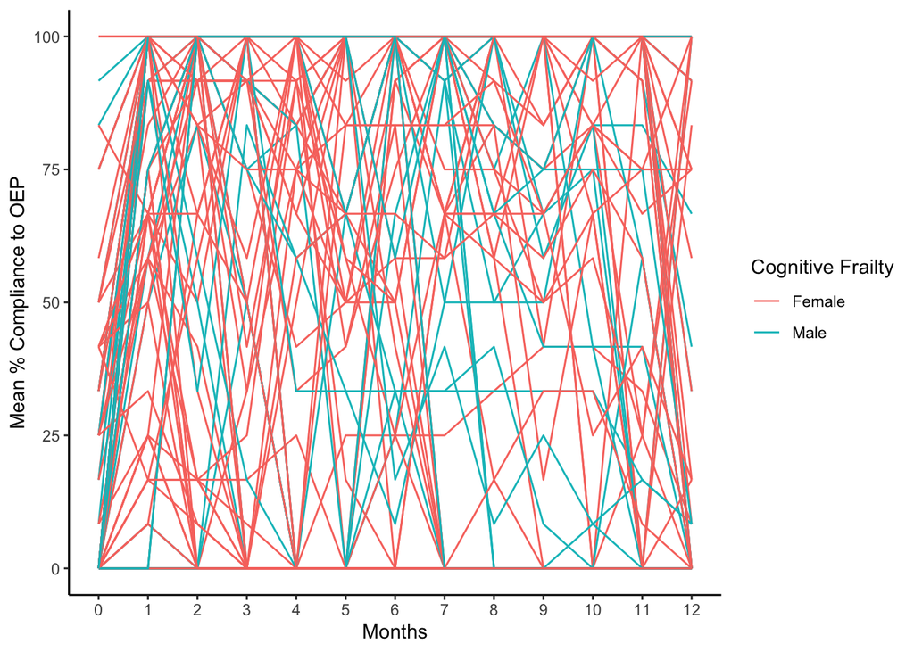

```r
compliancelong$Timepoint<-NA
compliancelong$Timepoint[compliancelong$time==1]<-0
compliancelong$Timepoint[compliancelong$time==2]<-1
compliancelong$Timepoint[compliancelong$time==3]<-2
compliancelong$Timepoint[compliancelong$time==4]<-3
compliancelong$Timepoint[compliancelong$time==5]<-4
compliancelong$Timepoint[compliancelong$time==6]<-5
compliancelong$Timepoint[compliancelong$time==7]<-6
compliancelong$Timepoint[compliancelong$time==8]<-7
compliancelong$Timepoint[compliancelong$time==9]<-8
compliancelong$Timepoint[compliancelong$time==10]<-9
compliancelong$Timepoint[compliancelong$time==11]<-10
compliancelong$Timepoint[compliancelong$time==12]<-11
compliancelong$Timepoint[compliancelong$time==13]<-12
compliancelong$Timepoint<-as.factor(compliancelong$Timepoint)

compliancelong$Sex[compliancelong$Sex==1]<-"Female"
compliancelong$Sex[compliancelong$Sex==2]<-"Male"

library(forcats)

compliance.cogfrail<-subset(compliancelong, CogFrail=="Yes")
library(forcats)

Compliance.Graph<- compliance.cogfrail %>%
  ggplot() + geom_line(aes(x=Timepoint, y=OEPCOMP, group=ID, color=Sex)) +
  labs(x="Months", y="Mean % Compliance to OEP") + ylim(0,100) + labs(color="Cognitive Frailty") +
  theme_bw() + theme(panel.border = element_blank(), panel.grid.major = element_blank(),
                     panel.grid.minor = element_blank(), axis.line = element_line(colour = "black"))
Compliance.Graph
```

# 7) Supplementary Material S3 - Sex differences in monthly compliance

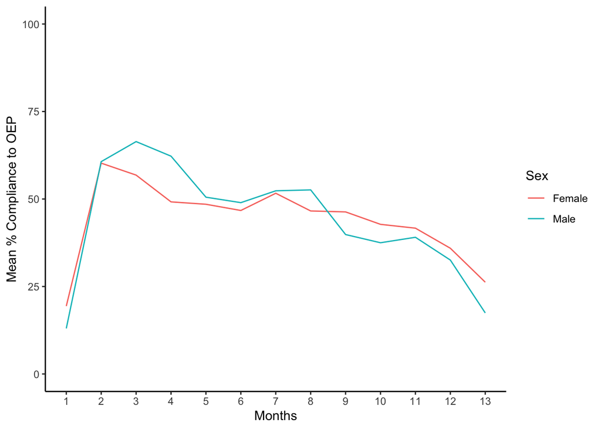

```r
comply.2<-lmer(OEPCOMP~factor(time)*Sex + 1 + (1|ID), compliance.cogfrail)
emms.2<-as.data.frame(lsmeans(comply.2, ~factor(time)|Sex))

Compliance.Graph.3<- emms.2 %>%
  ggplot() + geom_line(aes(x=time, y=lsmean, color=Sex)) +
  labs(x="Months", y="Mean % Compliance to OEP") + ylim(0,100) + scale_x_continuous(breaks=seq(0,13,by=1)) +
  labs(color="Sex") +
  theme_bw() + theme(panel.border = element_blank(), panel.grid.major = element_blank(),
                     panel.grid.minor = element_blank(), axis.line = element_line(colour = "black"))
Compliance.Graph.3
```

Estimated differences in average compliance for cognitively frail participants based on sex

```r
lsmeans(comply.2,~Sex)
```

```
## NOTE: Results may be misleading due to involvement in interactions
```

```
##  Sex    lsmean   SE df lower.CL upper.CL
##  Female   44.0 4.13 91     35.8     52.2
##  Male     44.1 5.70 91     32.8     55.4
##
## Results are averaged over the levels of: time
## Degrees-of-freedom method: kenward-roger
## Confidence level used: 0.95
```

```r
contrast(lsmeans(comply.2, ~Sex), "pairwise", adj="none") #No significant difference overall
```

```
## NOTE: Results may be misleading due to involvement in interactions
```

```
##  contrast      estimate   SE df t.ratio p.value
##  Female - Male   -0.091 7.04 91  -0.013  0.9897
##
## Results are averaged over the levels of: time
## Degrees-of-freedom method: kenward-roger
```

Estimated differences in average compliance for cogntiively frail participants based on sex by timepoint

```r
lsmeans(comply.2,~Sex|factor(time))
```

```
## time =  1:
##  Sex    lsmean   SE  df lower.CL upper.CL
##  Female   19.4 5.49 271     8.59     30.2
##  Male     13.0 7.58 271    -1.91     28.0
##
## time =  2:
##  Sex    lsmean   SE  df lower.CL upper.CL
##  Female   60.2 5.49 271    49.43     71.1
##  Male     60.7 7.58 271    45.75     75.6
##
## time =  3:
##  Sex    lsmean   SE  df lower.CL upper.CL
##  Female   56.8 5.49 271    46.02     67.6
##  Male     66.4 7.58 271    51.48     81.3
##
## time =  4:
##  Sex    lsmean   SE  df lower.CL upper.CL
##  Female   49.2 5.49 271    38.37     60.0
##  Male     62.2 7.58 271    47.31     77.2
##
## time =  5:
##  Sex    lsmean   SE  df lower.CL upper.CL
##  Female   48.5 5.49 271    37.68     59.3
##  Male     50.5 7.58 271    35.59     65.5
##
## time =  6:
##  Sex    lsmean   SE  df lower.CL upper.CL
##  Female   46.7 5.49 271    35.91     57.5
##  Male     49.0 7.58 271    34.03     63.9
##
## time =  7:
##  Sex    lsmean   SE  df lower.CL upper.CL
##  Female   51.6 5.49 271    40.83     62.5
##  Male     52.3 7.58 271    37.41     67.3
##
## time =  8:
##  Sex    lsmean   SE  df lower.CL upper.CL
##  Female   46.6 5.49 271    35.77     57.4
##  Male     52.6 7.58 271    37.67     67.5
##
```

[output cut: 12 more lines]

```
##  Female   41.7 5.49 271    30.85     52.5
##  Male     39.1 7.58 271    24.13     54.0
##
## time = 12:
##  Sex    lsmean   SE  df lower.CL upper.CL
##  Female   35.9 5.49 271    25.12     46.7
##  Male     32.6 7.58 271    17.62     47.5
##
## time = 13:
##  Sex    lsmean   SE  df lower.CL upper.CL
##  Female   26.2 5.49 271    15.42     37.0
##  Male     17.4 7.58 271     2.52     32.4
##
## Degrees-of-freedom method: kenward-roger
## Confidence level used: 0.95
```

```r
contrast(lsmeans(comply.2, ~Sex|factor(time)), "pairwise", adj="none") #No significant difference overall
```

```
## time =  1:
##  contrast      estimate   SE  df t.ratio p.value
##  Female - Male    6.378 9.36 271   0.681  0.4964
##
## time =  2:
##  contrast      estimate   SE  df t.ratio p.value
##  Female - Male   -0.431 9.36 271  -0.046  0.9633
##
## time =  3:
##  contrast      estimate   SE  df t.ratio p.value
##  Female - Male   -9.576 9.36 271  -1.023  0.3074
##
## time =  4:
##  contrast      estimate   SE  df t.ratio p.value
##  Female - Male  -13.059 9.36 271  -1.395  0.1643
##
## time =  5:
##  contrast      estimate   SE  df t.ratio p.value
##  Female - Male   -2.024 9.36 271  -0.216  0.8291
##
## time =  6:
##  contrast      estimate   SE  df t.ratio p.value
##  Female - Male   -2.237 9.36 271  -0.239  0.8114
##
## time =  7:
##  contrast      estimate   SE  df t.ratio p.value
##  Female - Male   -0.704 9.36 271  -0.075  0.9401
##
## time =  8:
##  contrast      estimate   SE  df t.ratio p.value
##  Female - Male   -6.019 9.36 271  -0.643  0.5209
##
## time =  9:
##  contrast      estimate   SE  df t.ratio p.value
##  Female - Male    6.468 9.36 271   0.691  0.4903
##
## time = 10:
##  contrast      estimate   SE  df t.ratio p.value
##  Female - Male    5.260 9.36 271   0.562  0.5748
##
## time = 11:
##  contrast      estimate   SE  df t.ratio p.value
##  Female - Male    2.604 9.36 271   0.278  0.7811
##
## time = 12:
##  contrast      estimate   SE  df t.ratio p.value
##  Female - Male    3.377 9.36 271   0.361  0.7186
##
## time = 13:
##  contrast      estimate   SE  df t.ratio p.value
##  Female - Male    8.782 9.36 271   0.938  0.3492
##
## Degrees-of-freedom method: kenward-roger
```

# 8) Table 2 - Primary and secondary outcomes at 12 months by cognitive frailty status and treatment group

Falls Incident Rate Ratio (Cognitively Frail Participants Only)

```r
mdl.nb<-glm.nb(Total_Falls~Group.1+scale(Gender,scale=FALSE)+offset(log(Total_Exposure/365)),subset(CogFrail,exclude==0))
print(summary(mdl.nb))
```

```
##
## Call:
## glm.nb(formula = Total_Falls ~ Group.1 + scale(Gender, scale = FALSE) +
##     offset(log(Total_Exposure/365)), data = subset(CogFrail,
##     exclude == 0), init.theta = 0.8504452563, link = log)
##
## Deviance Residuals:
##     Min       1Q   Median       3Q      Max
## -1.7635  -1.2540  -0.4557   0.2632   2.7073
##
## Coefficients:
##                              Estimate Std. Error z value Pr(>|z|)
## (Intercept)                    0.9108     0.1289   7.067 1.59e-12 ***
## Group.1Otago                  -0.4291     0.1934  -2.219  0.02650 *
## scale(Gender, scale = FALSE)   0.6250     0.1960   3.188  0.00143 **
## ---
## Signif. codes:  0 '***' 0.001 '**' 0.01 '*' 0.05 '.' 0.1 ' ' 1
##
## (Dispersion parameter for Negative Binomial(0.8504) family taken to be 1)
##
##     Null deviance: 210.58  on 191  degrees of freedom
## Residual deviance: 194.36  on 189  degrees of freedom
## AIC: 707.84
##
## Number of Fisher Scoring iterations: 1
##
##
##               Theta:  0.850
##           Std. Err.:  0.143
##
##  2 x log-likelihood:  -699.842
```

```r
SE<-sqrt(diag(vcovHC(mdl.nb,"HC1")))
p=2*pnorm(-abs(coef(mdl.nb)/SE))
print(cbind(coef(mdl.nb),SE,p))
```

```
##                                                SE            p
## (Intercept)                   0.9108292 0.1626557 2.146786e-08
## Group.1Otago                 -0.4291280 0.2110955 4.206649e-02
## scale(Gender, scale = FALSE)  0.6250177 0.2118145 3.169745e-03
```

```r
est<-cbind(Estimate=coef(mdl.nb),LL=coef(mdl.nb)-1.96*SE,UL=coef(mdl.nb)+1.96*SE)
exp_group<-exp(est)
print("Use these estimates and LL and UL for the 95% CI");exp_group
```

```
## [1] "Use these estimates and LL and UL for the 95% CI"
```

```
##                               Estimate       LL        UL
## (Intercept)                  2.4863834 1.807643 3.4199792
## Group.1Otago                 0.6510766 0.430471 0.9847369
## scale(Gender, scale = FALSE) 1.8682790 1.233507 2.8297099
```

```r
print("Significant effect of intervention on falls risk for participants with CogFrailty")
```

```
## [1] "Significant effect of intervention on falls risk for participants with CogFrailty"
```

Differences in total exposure based on group (Cognitively Frail Participants Only)

```r
exposurelm<-lm(TotalExposure~Group, subset(wide2, CogFrail=="Yes"))
lsmeans(exposurelm, ~Group)
```

```
##  Group lsmean   SE  df lower.CL upper.CL
##      0    345 8.10 190      329      361
##      1    329 8.36 190      312      345
##
## Confidence level used: 0.95
```

```r
contrast(lsmeans(exposurelm, ~Group), "trt.vs.ctrl", adj="none")
```

```
##  contrast estimate   SE  df t.ratio p.value
##  1 - 0       -16.1 11.6 190  -1.381  0.1690
```

Differences in the cumulative number of falls by group and cognitive frailty

```r
setwd("~/Desktop/Manuscripts/Ongoing Projects/ActionSeniors! Cognitive Frailty/")
Monthly_falls <- read_excel("AS_Monthly falls_Mar 20 2019.xlsx")
Monthly_falls<-subset(Monthly_falls, ID %in% wide2$ID)

data1c<-cbind(Monthly_falls,wide2$CogFrail,wide2$Group)
data1c<-subset(data1c,ID!=330)

data1c<-plyr::rename(data1c,c("Month_1_Cumulative"="MonthCumulative_1","Month_2_Cumulative"="MonthCumulative_2","Month_3_Cumulative"="MonthCumulative_3",
                              "Month_4_Cumulative"="MonthCumulative_4","Month_5_Cumulative"="MonthCumulative_5","Month_6_Cumulative"="MonthCumulative_6",
                              "Month_7_Cumulative"="MonthCumulative_7","Month_8_Cumulative"="MonthCumulative_8","Month_9_Cumulative"="MonthCumulative_9",
                              "Month_10_Cumulative"="MonthCumulative_10","Month_11_Cumulative"="MonthCumulative_11","Month_12_Cumulative"="MonthCumulative_12",
                              "Month_13_Cumulative"="MonthCumulative_13","wide2$CogFrail"="CogFrail","wide2$Group"="Group"))
data1c_CogFrail_EX<-subset(data1c,Group==1 & CogFrail=="Yes")
data1c_CogFrail_UC<-subset(data1c,Group==0 & CogFrail=="Yes")
data1c_NoCogFrail_EX<-subset(data1c,Group==1 & CogFrail=="No")
data1c_NoCogFrail_UC<-subset(data1c,Group==0 & CogFrail=="No")

print("CogFrail Exercise");apply(data1c_CogFrail_EX[c(2:14)], 2, function(x) length(which(!is.na(x)))) #count people with falls data
```

```
## [1] "CogFrail Exercise"
```

```
##  Month_1  Month_2  Month_3  Month_4  Month_5  Month_6  Month_7  Month_8
##       89       87       86       84       82       80       80       80
##  Month_9 Month_10 Month_11 Month_12 Month_13
##       78       77       76       75       75
```

```r
print("CogFrail Usual Care");apply(data1c_CogFrail_UC[c(2:14)], 2, function(x) length(which(!is.na(x)))) #count people with falls data
```

```
## [1] "CogFrail Usual Care"
```

```
##  Month_1  Month_2  Month_3  Month_4  Month_5  Month_6  Month_7  Month_8
##       98       97       95       94       93       89       89       87
##  Month_9 Month_10 Month_11 Month_12 Month_13
##       87       86       86       85       82
```

```r
print("No CogFrail Exercise");apply(data1c_NoCogFrail_EX[c(2:14)], 2, function(x) length(which(!is.na(x)))) #count people with falls data
```

```
## [1] "No CogFrail Exercise"
```

```
##  Month_1  Month_2  Month_3  Month_4  Month_5  Month_6  Month_7  Month_8
##       76       76       73       73       73       72       71       70
##  Month_9 Month_10 Month_11 Month_12 Month_13
##       70       70       68       68       67
```

```r
print("No CogFrail Usual Care");apply(data1c_NoCogFrail_UC[c(2:14)], 2, function(x) length(which(!is.na(x)))) #count people with falls data
```

```
## [1] "No CogFrail Usual Care"
```

```
##  Month_1  Month_2  Month_3  Month_4  Month_5  Month_6  Month_7  Month_8
##       70       70       69       68       67       66       65       65
##  Month_9 Month_10 Month_11 Month_12 Month_13
##       65       64       63       63       62
```

```r
data1c.stacked<-reshape(data1c,idvar="ID",varying=c(2:27),direction="long",sep="_")
data1c.stacked$time<-data1c.stacked$time-1

Fallsmeans<-data.frame(aggregate(MonthCumulative~Group*CogFrail+time,data1c.stacked,sum))
subset(Fallsmeans, CogFrail=="Yes")
```

```
##    Group CogFrail time MonthCumulative
## 3      0      Yes    0              14
## 4      1      Yes    0              10
## 7      0      Yes    1              41
## 8      1      Yes    1              24
## 11     0      Yes    2              60
## 12     1      Yes    2              41
## 15     0      Yes    3              81
## 16     1      Yes    3              49
## 19     0      Yes    4             111
## 20     1      Yes    4              61
## 23     0      Yes    5             125
## 24     1      Yes    5              70
## 27     0      Yes    6             148
## 28     1      Yes    6              77
## 31     0      Yes    7             163
## 32     1      Yes    7              91
## 35     0      Yes    8             176
## 36     1      Yes    8             102
## 39     0      Yes    9             194
## 40     1      Yes    9             114
## 43     0      Yes   10             214
## 44     1      Yes   10             124
## 47     0      Yes   11             236
## 48     1      Yes   11             132
## 51     0      Yes   12             244
## 52     1      Yes   12             136
```

Estimated differences in falls per person-year

```r
wide2.cogfrail<-subset(wide2, CogFrail=="Yes")

wide2.cogfrail$falls_ppy<-wide2.cogfrail$TotalFalls/(wide2.cogfrail$TotalExposure/365)

fallsppy_lm<-lm(falls_ppy~Group, wide2.cogfrail)
summary(fallsppy_lm)
```

```
##
## Call:
## lm(formula = falls_ppy ~ Group, data = wide2.cogfrail)
##
## Residuals:
##     Min      1Q  Median      3Q     Max
## -2.6359 -1.6359 -0.6359  0.4057 20.3641
##
## Coefficients:
##             Estimate Std. Error t value Pr(>|t|)
## (Intercept)   2.6359     0.3322   7.936 1.76e-13 ***
## Group        -1.0416     0.4772  -2.183   0.0303 *
## ---
## Signif. codes:  0 '***' 0.001 '**' 0.01 '*' 0.05 '.' 0.1 ' ' 1
##
## Residual standard error: 3.305 on 190 degrees of freedom
## Multiple R-squared:  0.02446,    Adjusted R-squared:  0.01932
## F-statistic: 4.763 on 1 and 190 DF,  p-value: 0.0303
```

```r
lsmeans(fallsppy_lm, ~Group)
```

```
##  Group lsmean    SE  df lower.CL upper.CL
##      0   2.64 0.332 190    1.981     3.29
##      1   1.59 0.343 190    0.918     2.27
##
## Confidence level used: 0.95
```

```r
contrast(lsmeans(fallsppy_lm, ~~Group), "trt.vs.ctrl", adj="none")
```

```
##  contrast estimate    SE  df t.ratio p.value
##  1 - 0       -1.04 0.477 190  -2.183  0.0303
```

Differences in exposure time

```r
expopsure_lm<-lm(TotalExposure~Group, wide2.cogfrail)
summary(expopsure_lm)
```

```
##
## Call:
## lm(formula = TotalExposure ~ Group, data = wide2.cogfrail)
##
## Residuals:
##     Min      1Q  Median      3Q     Max
## -331.80   20.20   20.20   36.28   92.20
##
## Coefficients:
##             Estimate Std. Error t value Pr(>|t|)
## (Intercept)  344.798      8.104  42.545   <2e-16 ***
## Group        -16.078     11.645  -1.381    0.169
## ---
## Signif. codes:  0 '***' 0.001 '**' 0.01 '*' 0.05 '.' 0.1 ' ' 1
##
## Residual standard error: 80.64 on 190 degrees of freedom
## Multiple R-squared:  0.009933,   Adjusted R-squared:  0.004722
## F-statistic: 1.906 on 1 and 190 DF,  p-value: 0.169
```

```r
lsmeans(expopsure_lm, ~Group)
```

```
##  Group lsmean   SE  df lower.CL upper.CL
##      0    345 8.10 190      329      361
##      1    329 8.36 190      312      345
##
## Confidence level used: 0.95
```

```r
contrast(lsmeans(expopsure_lm, ~~Group), "trt.vs.ctrl", adj="none")
```

```
##  contrast estimate   SE  df t.ratio p.value
##  1 - 0       -16.1 11.6 190  -1.381  0.1690
```

PPA

```r
PPA_lm<-lmer(PPA~Group.1*factor(time) + scale(Gender,scale=FALSE) + PPAbaseline + (1|ID), subset(data2, exclude == 0 & CogFrail=="Yes"))
anova(PPA_lm)
```

```
## Type III Analysis of Variance Table with Satterthwaite's method
##                              Sum Sq Mean Sq NumDF  DenDF F value    Pr(>F)
## Group.1                       0.301   0.301     1 152.46  0.5875    0.4446
## factor(time)                  0.571   0.571     1 145.68  1.1135    0.2931
## scale(Gender, scale = FALSE)  0.655   0.655     1 153.68  1.2781    0.2600
## PPAbaseline                  36.057  36.057     1 154.52 70.3677 2.892e-14 ***
## Group.1:factor(time)          0.663   0.663     1 145.81  1.2935    0.2573
## ---
## Signif. codes:  0 '***' 0.001 '**' 0.01 '*' 0.05 '.' 0.1 ' ' 1
```

```r
lsmeans(PPA_lm, ~Group.1|factor(time))
```

```
## time = 2:
##  Group.1   lsmean    SE  df lower.CL upper.CL
##  Interview   2.25 0.103 257     2.05     2.46
##  Otago       2.26 0.109 257     2.04     2.47
##
## time = 3:
##  Group.1   lsmean    SE  df lower.CL upper.CL
##  Interview   2.26 0.105 261     2.05     2.47
##  Otago       2.07 0.112 263     1.85     2.29
##
## Results are averaged over the levels of: Gender
## Degrees-of-freedom method: kenward-roger
## Confidence level used: 0.95
```

```r
contrast(lsmeans(PPA_lm, ~Group.1|factor(time)), "trt.vs.ctrl", adj="none")
```

```
## time = 2:
##  contrast          estimate    SE  df t.ratio p.value
##  Otago - Interview  0.00168 0.148 259   0.011  0.9909
##
## time = 3:
##  contrast          estimate    SE  df t.ratio p.value
##  Otago - Interview -0.19087 0.151 265  -1.260  0.2087
##
## Results are averaged over the levels of: Gender
## Degrees-of-freedom method: kenward-roger
```

```r
confint(contrast(lsmeans(PPA_lm, ~Group.1|factor(time)), "trt.vs.ctrl", adj="none"))
```

```
## time = 2:
##  contrast          estimate    SE  df lower.CL upper.CL
##  Otago - Interview  0.00168 0.148 259   -0.290    0.293
##
## time = 3:
##  contrast          estimate    SE  df lower.CL upper.CL
##  Otago - Interview -0.19087 0.151 265   -0.489    0.107
##
## Results are averaged over the levels of: Gender
## Degrees-of-freedom method: kenward-roger
## Confidence level used: 0.95
```

```r
print("No significant differences for CogFrail participants")
```

```
## [1] "No significant differences for CogFrail participants"
```

SPPB

```r
SPPB_lm<-lmer(SPPB~Group.1*factor(time) + scale(Gender,scale=FALSE) + SPPBbaseline + (1|ID), subset(data2, exclude == 0 & CogFrail=="Yes"))
anova(SPPB_lm)
```

```
## Type III Analysis of Variance Table with Satterthwaite's method
##                               Sum Sq Mean Sq NumDF  DenDF  F value  Pr(>F)
## Group.1                        0.159   0.159     1 153.83   0.1528 0.69642
## factor(time)                   0.925   0.925     1 141.41   0.8904 0.34699
## scale(Gender, scale = FALSE)   2.948   2.948     1 154.34   2.8390 0.09402 .
## SPPBbaseline                 105.198 105.198     1 156.07 101.3041 < 2e-16 ***
## Group.1:factor(time)           1.513   1.513     1 141.45   1.4572 0.22940
## ---
## Signif. codes:  0 '***' 0.001 '**' 0.01 '*' 0.05 '.' 0.1 ' ' 1
```

```r
lsmeans(SPPB_lm, ~Group.1|factor(time))
```

```
## time = 2:
##  Group.1   lsmean    SE  df lower.CL upper.CL
##  Interview   7.05 0.194 211     6.67     7.43
##  Otago       7.10 0.204 213     6.70     7.50
##
## time = 3:
##  Group.1   lsmean    SE  df lower.CL upper.CL
##  Interview   7.08 0.197 219     6.69     7.47
##  Otago       6.84 0.209 224     6.43     7.25
##
## Results are averaged over the levels of: Gender
## Degrees-of-freedom method: kenward-roger
## Confidence level used: 0.95
```

```r
contrast(lsmeans(SPPB_lm, ~Group.1|factor(time)), "trt.vs.ctrl", adj="none")
```

```
## time = 2:
##  contrast          estimate    SE  df t.ratio p.value
##  Otago - Interview   0.0492 0.277 214   0.178  0.8592
##
## time = 3:
##  contrast          estimate    SE  df t.ratio p.value
##  Otago - Interview  -0.2459 0.283 223  -0.870  0.3853
##
## Results are averaged over the levels of: Gender
## Degrees-of-freedom method: kenward-roger
```

```r
confint(contrast(lsmeans(SPPB_lm, ~Group.1|factor(time)), "trt.vs.ctrl", adj="none"))
```

```
## time = 2:
##  contrast          estimate    SE  df lower.CL upper.CL
##  Otago - Interview   0.0492 0.277 214   -0.496    0.595
##
## time = 3:
##  contrast          estimate    SE  df lower.CL upper.CL
##  Otago - Interview  -0.2459 0.283 223   -0.803    0.311
##
## Results are averaged over the levels of: Gender
## Degrees-of-freedom method: kenward-roger
## Confidence level used: 0.95
```

```r
print("No significant effects")
```

```
## [1] "No significant effects"
```

Gait Speed

```r
GS_lm<-lmer(GaitSpeed~Group.1*factor(time) + scale(Gender,scale=FALSE) + GaitSpeedbaseline + (1|ID), subset(data2, exclude == 0 & CogFrail=="Yes"))
anova(GS_lm)
```

```
## Type III Analysis of Variance Table with Satterthwaite's method
##                               Sum Sq Mean Sq NumDF  DenDF  F value  Pr(>F)
## Group.1                      0.00007 0.00007     1 149.35   0.0090 0.92460
## factor(time)                 0.00317 0.00317     1 137.51   0.4199 0.51806
## scale(Gender, scale = FALSE) 0.02838 0.02838     1 149.82   3.7635 0.05426 .
## GaitSpeedbaseline            2.06864 2.06864     1 148.11 274.2928 < 2e-16 ***
## Group.1:factor(time)         0.01911 0.01911     1 137.51   2.5336 0.11374
## ---
## Signif. codes:  0 '***' 0.001 '**' 0.01 '*' 0.05 '.' 0.1 ' ' 1
```

```r
lsmeans(GS_lm, ~Group.1|factor(time))
```

```
## time = 2:
##  Group.1   lsmean     SE  df lower.CL upper.CL
##  Interview  0.774 0.0158 217    0.743    0.806
##  Otago      0.793 0.0166 219    0.760    0.826
##
## time = 3:
##  Group.1   lsmean     SE  df lower.CL upper.CL
##  Interview  0.784 0.0160 225    0.753    0.816
##  Otago      0.770 0.0170 229    0.736    0.803
##
## Results are averaged over the levels of: Gender
## Degrees-of-freedom method: kenward-roger
## Confidence level used: 0.95
```

```r
contrast(lsmeans(GS_lm, ~Group.1|factor(time)), "trt.vs.ctrl", adj="none")
```

```
## time = 2:
##  contrast          estimate     SE  df t.ratio p.value
##  Otago - Interview   0.0185 0.0225 220   0.820  0.4133
##
## time = 3:
##  contrast          estimate     SE  df t.ratio p.value
##  Otago - Interview  -0.0146 0.0230 230  -0.635  0.5259
##
## Results are averaged over the levels of: Gender
## Degrees-of-freedom method: kenward-roger
```

```r
confint(contrast(lsmeans(GS_lm, ~Group.1|factor(time)), "trt.vs.ctrl", adj="none"))
```

```
## time = 2:
##  contrast          estimate     SE  df lower.CL upper.CL
##  Otago - Interview   0.0185 0.0225 220  -0.0259   0.0629
##
## time = 3:
##  contrast          estimate     SE  df lower.CL upper.CL
##  Otago - Interview  -0.0146 0.0230 230  -0.0600   0.0308
##
## Results are averaged over the levels of: Gender
## Degrees-of-freedom method: kenward-roger
## Confidence level used: 0.95
```

```r
print("No significant effects for CogFrail participants")
```

```
## [1] "No significant effects for CogFrail participants"
```

MoCA

```r
emm_options(opt.digits = FALSE)

MoCA_lm<-lmer(MoCA~Group.1*factor(time) + scale(Gender,scale=FALSE) + MoCAbaseline + (1|ID), subset(data2, exclude==0 & CogFrail=="Yes"))
anova(MoCA_lm)
```

```
## Type III Analysis of Variance Table with Satterthwaite's method
##                               Sum Sq Mean Sq NumDF  DenDF F value    Pr(>F)
## Group.1                       72.222  72.222     1 152.12  7.4933  0.006931 **
## factor(time)                  59.051  59.051     1 153.94  6.1268  0.014398 *
## scale(Gender, scale = FALSE)   4.028   4.028     1 155.04  0.4180  0.518914
## MoCAbaseline                 261.594 261.594     1 162.84 27.1415 5.653e-07 ***
## Group.1:factor(time)           0.620   0.620     1 153.94  0.0643  0.800129
## ---
## Signif. codes:  0 '***' 0.001 '**' 0.01 '*' 0.05 '.' 0.1 ' ' 1
```

```r
lsmeans(MoCA_lm, ~Group.1|factor(time))
```

```
## time = 2:
##  Group.1     lsmean        SE     df lower.CL upper.CL
##  Interview 24.25745 0.3560419 289.17 23.55669 24.95821
##  Otago     23.14439 0.3790250 289.24 22.39840 23.89039
##
## time = 3:
##  Group.1     lsmean        SE     df lower.CL upper.CL
##  Interview 23.26849 0.3631847 289.25 22.55367 23.98331
##  Otago     22.33920 0.3890191 289.33 21.57354 23.10487
##
## Results are averaged over the levels of: Gender
## Degrees-of-freedom method: kenward-roger
## Confidence level used: 0.95
```

```r
contrast(lsmeans(MoCA_lm, ~Group.1|factor(time)), "trt.vs.ctrl", adj="none")
```

```
## time = 2:
##  contrast            estimate        SE     df t.ratio p.value
##  Otago - Interview -1.1130551 0.5129257 289.63  -2.170  0.0308
##
## time = 3:
##  contrast            estimate        SE     df t.ratio p.value
##  Otago - Interview -0.9292808 0.5276011 289.69  -1.761  0.0792
##
## Results are averaged over the levels of: Gender
## Degrees-of-freedom method: kenward-roger
```

```r
confint(contrast(lsmeans(MoCA_lm, ~Group.1|factor(time)), "trt.vs.ctrl", adj="none"))
```

```
## time = 2:
##  contrast            estimate        SE     df  lower.CL   upper.CL
##  Otago - Interview -1.1130551 0.5129257 289.63 -2.122589 -0.1035208
##
## time = 3:
##  contrast            estimate        SE     df  lower.CL   upper.CL
##  Otago - Interview -0.9292808 0.5276011 289.69 -1.967698  0.1091367
##
## Results are averaged over the levels of: Gender
## Degrees-of-freedom method: kenward-roger
## Confidence level used: 0.95
```

```r
print("No significant differences at 12 months")
```

```
## [1] "No significant differences at 12 months"
```

# 9) Figure 2 - Accumulation of falls by treatment group for cognitively frail participants

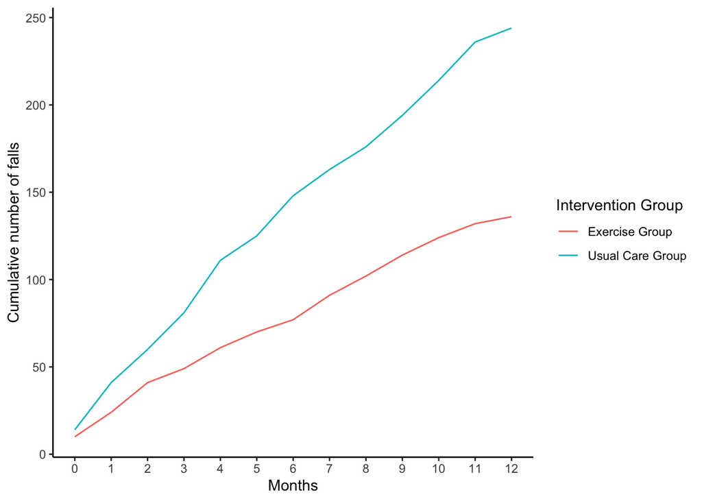

```r
Fallsmeans$GroupCogFrail<-NA
Fallsmeans$GroupCogFrail[Fallsmeans$Group==0 & Fallsmeans$CogFrail=="Yes"]<-"Usual Care Group"
Fallsmeans$GroupCogFrail[Fallsmeans$Group==1 & Fallsmeans$CogFrail=="Yes"]<-"Exercise Group"

Fallsmeans.cogfrail<-subset(Fallsmeans, CogFrail=="Yes")

Cumulativefalls.Graph<- Fallsmeans.cogfrail %>%
  ggplot() + geom_line(aes(x=time, y=MonthCumulative, color=GroupCogFrail)) +
  labs(x="Months", y="Cumulative number of falls") + labs(color="Intervention Group") +
  scale_x_continuous(breaks=seq(0,13,by=1)) + scale_y_continuous(breaks=seq(0,300,by=50))+
  theme_bw() + theme(panel.border = element_blank(), panel.grid.major = element_blank(),
                     panel.grid.minor = element_blank(), axis.line = element_line(colour = "black"))
Cumulativefalls.Graph
```

# 10) Table 3 - Primary and secondary outcomes at 12 months in exercise group based on cognitive frailty status and compliance to the intervention

Subset Exercise Group participants by cognitive frailty status

```r
CogFrail_OEP<-subset(OEP2, CogFrail=="Yes")
```

Falls Incident Rate Ratio (Cognitively Frail Participants)

```r
mdl.nb<-glm.nb(TotalFalls~Compliant+scale(Gender,scale=FALSE)+offset(log(TotalExposure/365)),subset(OEP2,CogFrail=="Yes" & exclude==0))
print(summary(mdl.nb))
```

```
##
## Call:
## glm.nb(formula = TotalFalls ~ Compliant + scale(Gender, scale = FALSE) +
##     offset(log(TotalExposure/365)), data = subset(OEP2, CogFrail ==
##     "Yes" & exclude == 0), init.theta = 1.180677101, link = log)
##
## Deviance Residuals:
##     Min       1Q   Median       3Q      Max
## -1.6031  -1.3316  -0.2480   0.3115   2.6463
##
## Coefficients:
##                              Estimate Std. Error z value Pr(>|z|)
## (Intercept)                   0.51089    0.19820   2.578  0.00995 **
## CompliantYes                 -0.05775    0.26380  -0.219  0.82671
## scale(Gender, scale = FALSE)  0.50746    0.26745   1.897  0.05778 .
## ---
## Signif. codes:  0 '***' 0.001 '**' 0.01 '*' 0.05 '.' 0.1 ' ' 1
##
## (Dispersion parameter for Negative Binomial(1.1807) family taken to be 1)
##
##     Null deviance: 97.972  on 92  degrees of freedom
## Residual deviance: 94.151  on 90  degrees of freedom
## AIC: 308.12
##
## Number of Fisher Scoring iterations: 1
##
##
##               Theta:  1.181
##           Std. Err.:  0.358
##
##  2 x log-likelihood:  -300.123
```

```r
SE<-sqrt(diag(vcovHC(mdl.nb,"HC1")))
p=2*pnorm(-abs(coef(mdl.nb)/SE))
print(cbind(coef(mdl.nb),SE,p))
```

```
##                                                 SE          p
## (Intercept)                   0.51088657 0.2136335 0.01678352
## CompliantYes                 -0.05775117 0.2876300 0.84086837
## scale(Gender, scale = FALSE)  0.50746132 0.2951436 0.08554691
```

```r
est<-cbind(Estimate=coef(mdl.nb),LL=coef(mdl.nb)-1.96*SE,UL=coef(mdl.nb)+1.96*SE)
exp_group<-exp(est)
print("Use these estimates and LL and UL for the 95% CI");exp_group
```

```
## [1] "Use these estimates and LL and UL for the 95% CI"
```

```
##                               Estimate        LL       UL
## (Intercept)                  1.6667682 1.0965457 2.533516
## CompliantYes                 0.9438848 0.5371349 1.658649
## scale(Gender, scale = FALSE) 1.6610689 0.9314430 2.962231
```

```r
print("No significant effect of compliance for CogFrail participants")
```

```
## [1] "No significant effect of compliance for CogFrail participants"
```

Falls Per Person-Year (Cognitively Frail Participants)

```r
CogFrail_OEP$falls_ppy<-CogFrail_OEP$TotalFalls/(CogFrail_OEP$TotalExposure/365)

fallsppy_comply<-lm(falls_ppy~Compliant, CogFrail_OEP)
summary(fallsppy_comply)
```

```
##
## Call:
## lm(formula = falls_ppy ~ Compliant, data = CogFrail_OEP)
##
## Residuals:
##     Min      1Q  Median      3Q     Max
## -1.5970 -1.5918 -0.5918  0.4082 11.4030
##
## Coefficients:
##               Estimate Std. Error t value Pr(>|t|)
## (Intercept)   1.597031   0.339473   4.704 9.04e-06 ***
## CompliantYes -0.005194   0.467679  -0.011    0.991
## ---
## Signif. codes:  0 '***' 0.001 '**' 0.01 '*' 0.05 '.' 0.1 ' ' 1
##
## Residual standard error: 2.252 on 91 degrees of freedom
## Multiple R-squared:  1.355e-06,  Adjusted R-squared:  -0.01099
## F-statistic: 0.0001233 on 1 and 91 DF,  p-value: 0.9912
```

```r
lsmeans(fallsppy_comply, ~Compliant)
```

```
##  Compliant   lsmean        SE df  lower.CL upper.CL
##  No        1.597031 0.3394726 91 0.9227104 2.271351
##  Yes       1.591837 0.3216866 91 0.9528458 2.230828
##
## Confidence level used: 0.95
```

```r
contrast(lsmeans(fallsppy_comply, ~~Compliant), "trt.vs.ctrl", adj="none")
```

```
##  contrast    estimate        SE df t.ratio p.value
##  Yes - No -0.00519416 0.4676792 91  -0.011  0.9912
```

PPA

```r
PPA_lm<-lmer(PPA~Compliant*factor(time) + scale(Gender,scale=FALSE) + PPAbaseline + (1|ID), subset(OEP3, exclude == 0 & CogFrail=="Yes"))
anova(PPA_lm)
```

```
## Type III Analysis of Variance Table with Satterthwaite's method
##                               Sum Sq Mean Sq NumDF  DenDF F value    Pr(>F)
## Compliant                     0.5842  0.5842     1 71.849  1.4661    0.2299
## factor(time)                  1.0092  1.0092     1 69.300  2.5327    0.1161
## scale(Gender, scale = FALSE)  0.0005  0.0005     1 72.002  0.0013    0.9711
## PPAbaseline                  18.5160 18.5160     1 74.091 46.4685 2.144e-09 ***
## Compliant:factor(time)        0.0039  0.0039     1 69.317  0.0098    0.9213
## ---
## Signif. codes:  0 '***' 0.001 '**' 0.01 '*' 0.05 '.' 0.1 ' ' 1
```

```r
lsmeans(PPA_lm, ~Compliant|factor(time))
```

```
## time = 2:
##  Compliant   lsmean        SE     df lower.CL upper.CL
##  No        2.080115 0.1723967 113.73 1.738590 2.421640
##  Yes       2.308562 0.1243657 112.47 2.062158 2.554965
##
## time = 3:
##  Compliant   lsmean        SE     df lower.CL upper.CL
##  No        1.906744 0.1779640 117.70 1.554318 2.259171
##  Yes       2.112162 0.1267213 114.98 1.861151 2.363173
##
## Results are averaged over the levels of: Gender
## Degrees-of-freedom method: kenward-roger
## Confidence level used: 0.95
```

```r
contrast(lsmeans(PPA_lm, ~Compliant|factor(time)), "trt.vs.ctrl", adj="none")
```

```
## time = 2:
##  contrast  estimate        SE     df t.ratio p.value
##  Yes - No 0.2284471 0.2105923 113.81   1.085  0.2803
##
## time = 3:
##  contrast  estimate        SE     df t.ratio p.value
##  Yes - No 0.2054174 0.2167472 117.41   0.948  0.3452
##
## Results are averaged over the levels of: Gender
## Degrees-of-freedom method: kenward-roger
```

```r
confint(contrast(lsmeans(PPA_lm, ~Compliant|factor(time)), "trt.vs.ctrl", adj="none"))
```

```
## time = 2:
##  contrast  estimate        SE     df   lower.CL  upper.CL
##  Yes - No 0.2284471 0.2105923 113.81 -0.1887421 0.6456362
##
## time = 3:
##  contrast  estimate        SE     df   lower.CL  upper.CL
##  Yes - No 0.2054174 0.2167472 117.41 -0.2238234 0.6346581
##
## Results are averaged over the levels of: Gender
## Degrees-of-freedom method: kenward-roger
## Confidence level used: 0.95
```

```r
print("No significant effects")
```

```
## [1] "No significant effects"
```

SPPB

```r
SPPB_lm<-lmer(SPPB~Compliant*factor(time) + scale(Gender,scale=FALSE) + SPPBbaseline + 1 + (1|ID), subset(OEP3, exclude == 0 & CogFrail =="Yes"))
anova(SPPB_lm)
```

```
## Type III Analysis of Variance Table with Satterthwaite's method
##                               Sum Sq Mean Sq NumDF  DenDF F value   Pr(>F)
## Compliant                     4.6534  4.6534     1 69.111  4.4001  0.03960 *
## factor(time)                  5.1663  5.1663     1 64.929  4.8851  0.03062 *
## scale(Gender, scale = FALSE)  0.0401  0.0401     1 69.967  0.0380  0.84610
## SPPBbaseline                 28.1636 28.1636     1 71.685 26.6304 2.11e-06 ***
## Compliant:factor(time)        6.6583  6.6583     1 64.904  6.2958  0.01461 *
## ---
## Signif. codes:  0 '***' 0.001 '**' 0.01 '*' 0.05 '.' 0.1 ' ' 1
```

```r
lsmeans(SPPB_lm, ~Compliant|factor(time))
```

```
## time = 2:
##  Compliant   lsmean        SE     df lower.CL upper.CL
##  No        7.050735 0.3253708 101.36 6.405315 7.696155
##  Yes       7.316407 0.2344782 101.25 6.851278 7.781535
##
## time = 3:
##  Compliant   lsmean        SE     df lower.CL upper.CL
##  No        6.149990 0.3351296 106.80 5.485621 6.814359
##  Yes       7.373530 0.2402945 105.92 6.897119 7.849942
##
## Results are averaged over the levels of: Gender
## Degrees-of-freedom method: kenward-roger
## Confidence level used: 0.95
```

```r
contrast(lsmeans(SPPB_lm, ~Compliant|factor(time)), "trt.vs.ctrl", adj="none")
```

```
## time = 2:
##  contrast  estimate        SE     df t.ratio p.value
##  Yes - No 0.2656712 0.3973166 101.46   0.669  0.5052
##
## time = 3:
##  contrast  estimate        SE     df t.ratio p.value
##  Yes - No 1.2235405 0.4091130 106.89   2.991  0.0035
##
## Results are averaged over the levels of: Gender
## Degrees-of-freedom method: kenward-roger
```

```r
confint(contrast(lsmeans(SPPB_lm, ~Compliant|factor(time)), "trt.vs.ctrl", adj="none"))
```

```
## time = 2:
##  contrast  estimate        SE     df   lower.CL upper.CL
##  Yes - No 0.2656712 0.3973166 101.46 -0.5224542 1.053797
##
## time = 3:
##  contrast  estimate        SE     df   lower.CL upper.CL
##  Yes - No 1.2235405 0.4091130 106.89  0.4125126 2.034568
##
## Results are averaged over the levels of: Gender
## Degrees-of-freedom method: kenward-roger
## Confidence level used: 0.95
```

```r
print("Higher compliance among CogFrail participants was associated with better SPPB score at 12 months")
```

```
## [1] "Higher compliance among CogFrail participants was associated with better SPPB score at 12 months"
```

Gait Speed

```r
GS_lm<-lmer(GaitSpeed~Compliant*factor(time) + scale(Gender,scale=FALSE) + GaitSpeedbaseline + 1 + (1|ID), subset(OEP3, exclude == 0 & CogFrail=="Yes"))
anova(GS_lm)
```

```
## Type III Analysis of Variance Table with Satterthwaite's method
##                               Sum Sq Mean Sq NumDF  DenDF  F value  Pr(>F)
## Compliant                    0.00142 0.00142     1 66.369   0.2075 0.65020
## factor(time)                 0.03219 0.03219     1 62.333   4.7192 0.03364 *
## scale(Gender, scale = FALSE) 0.00981 0.00981     1 67.000   1.4376 0.23474
## GaitSpeedbaseline            0.88766 0.88766     1 66.696 130.1200 < 2e-16 ***
## Compliant:factor(time)       0.02699 0.02699     1 62.279   3.9562 0.05110 .
## ---
## Signif. codes:  0 '***' 0.001 '**' 0.01 '*' 0.05 '.' 0.1 ' ' 1
```

```r
lsmeans(GS_lm, ~Compliant|factor(time))
```

```
## time = 2:
##  Compliant    lsmean         SE     df  lower.CL  upper.CL
##  No        0.7933151 0.02483879 105.35 0.7440663 0.8425639
##  Yes       0.7750403 0.01796865 104.37 0.7394093 0.8106713
##
## time = 3:
##  Compliant    lsmean         SE     df  lower.CL  upper.CL
##  No        0.7296384 0.02560990 110.46 0.6788879 0.7803889
##  Yes       0.7722466 0.01845081 108.96 0.7356776 0.8088157
##
## Results are averaged over the levels of: Gender
## Degrees-of-freedom method: kenward-roger
## Confidence level used: 0.95
```

```r
contrast(lsmeans(GS_lm, ~Compliant|factor(time)), "trt.vs.ctrl", adj="none")
```

```
## time = 2:
##  contrast    estimate         SE     df t.ratio p.value
##  Yes - No -0.01827477 0.03032141 105.40  -0.603  0.5480
##
## time = 3:
##  contrast    estimate         SE     df t.ratio p.value
##  Yes - No  0.04260823 0.03127538 110.57   1.362  0.1759
##
## Results are averaged over the levels of: Gender
## Degrees-of-freedom method: kenward-roger
```

```r
confint(contrast(lsmeans(GS_lm, ~Compliant|factor(time)), "trt.vs.ctrl", adj="none"))
```

```
## time = 2:
##  contrast    estimate         SE     df    lower.CL   upper.CL
##  Yes - No -0.01827477 0.03032141 105.40 -0.07839385 0.04184431
##
## time = 3:
##  contrast    estimate         SE     df    lower.CL   upper.CL
##  Yes - No  0.04260823 0.03127538 110.57 -0.01936870 0.10458517
##
## Results are averaged over the levels of: Gender
## Degrees-of-freedom method: kenward-roger
## Confidence level used: 0.95
```

```r
print("No significant effects")
```

```
## [1] "No significant effects"
```

MoCA

```r
MoCA_lm<-lmer(MoCA~Compliant*factor(time) + scale(Gender,scale=FALSE) + MoCAbaseline + 1 + (1|ID), subset(OEP3, exclude==0 & CogFrail =="Yes"))
anova(MoCA_lm)
```

```
## Type III Analysis of Variance Table with Satterthwaite's method
##                               Sum Sq Mean Sq NumDF  DenDF F value   Pr(>F)
## Compliant                      1.707   1.707     1 69.884  0.1520 0.697788
## factor(time)                  34.940  34.940     1 70.817  3.1117 0.082047 .
## scale(Gender, scale = FALSE)   2.499   2.499     1 70.717  0.2226 0.638529
## MoCAbaseline                 118.639 118.639     1 78.310 10.5658 0.001699 **
## Compliant:factor(time)        19.495  19.495     1 70.805  1.7362 0.191866
## ---
## Signif. codes:  0 '***' 0.001 '**' 0.01 '*' 0.05 '.' 0.1 ' ' 1
```

```r
lsmeans(MoCA_lm, ~Compliant|factor(time))
```

```
## time = 2:
##  Compliant   lsmean        SE     df lower.CL upper.CL
##  No        23.41594 0.6923225 131.32 22.04639 24.78549
##  Yes       22.86760 0.5120030 131.50 21.85477 23.88043
##
## time = 3:
##  Compliant   lsmean        SE     df lower.CL upper.CL
##  No        21.55419 0.7401408 131.51 20.09007 23.01831
##  Yes       22.59827 0.5174203 131.55 21.57473 23.62181
##
## Results are averaged over the levels of: Gender
## Degrees-of-freedom method: kenward-roger
## Confidence level used: 0.95
```

```r
contrast(lsmeans(MoCA_lm, ~Compliant|factor(time)), "trt.vs.ctrl", adj="none")
```

```
## time = 2:
##  contrast   estimate        SE     df t.ratio p.value
##  Yes - No -0.5483443 0.8540113 131.53  -0.642  0.5219
##
## time = 3:
##  contrast   estimate        SE     df t.ratio p.value
##  Yes - No  1.0440793 0.9021860 131.68   1.157  0.2493
##
## Results are averaged over the levels of: Gender
## Degrees-of-freedom method: kenward-roger
```

```r
confint(contrast(lsmeans(MoCA_lm, ~Compliant|factor(time)), "trt.vs.ctrl", adj="none"))
```

```
## time = 2:
##  contrast   estimate        SE     df   lower.CL upper.CL
##  Yes - No -0.5483443 0.8540113 131.53 -2.2377193 1.141031
##
## time = 3:
##  contrast   estimate        SE     df   lower.CL upper.CL
##  Yes - No  1.0440793 0.9021860 131.68 -0.7405743 2.828733
##
## Results are averaged over the levels of: Gender
## Degrees-of-freedom method: kenward-roger
## Confidence level used: 0.95
```

```r
print("No significant differences")
```

```
## [1] "No significant differences"
```